# Librarian Census Data Code

## Where do you usually get funding or support for your trainings in LIS?

- from the work place (private sponsorship)
- from the government (scholarships, free trainings and seminars, etc)
- personal funding (personally attended trainings and symposiums and shouldered most of the expenses)
- NA (Have not attended CPD Trainings yet)

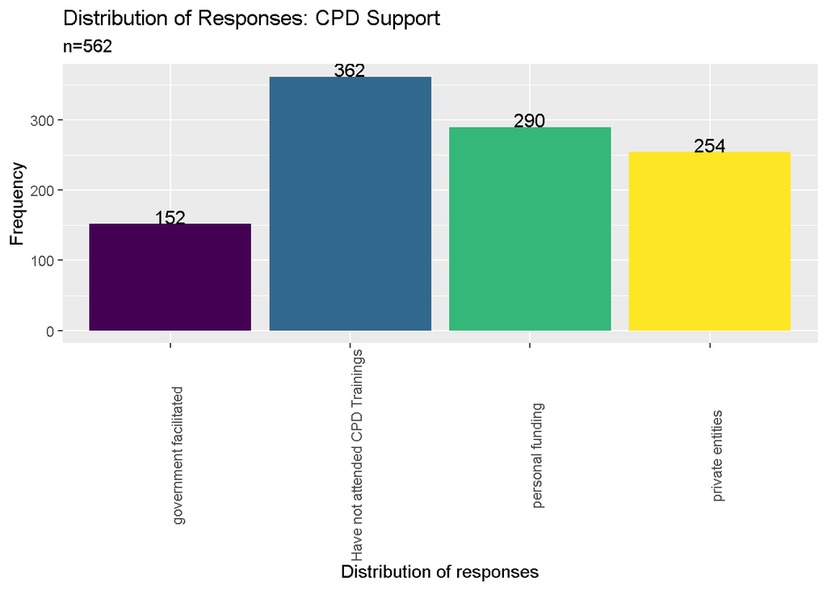

```r
# Combine columns: cpdsupport1, cpdsupport2, cpdsupport3
dataset$cpdsupport <- paste(dataset$cpdsupport1, dataset$cpdsupport2, dataset$cpdsupport3)
# Create new columns: support_inhouse, sgovernment, sprivate, sxattended
dataset <- transform(dataset, support_self = grepl("personal", cpdsupport), support_government = grepl("government", cpdsupport), support_private = grepl("private", cpdsupport), support_xattended = grepl("attended", cpdsupport))
# Summarize by counting the TRUE values per materials
dataset %>%
summarise("personal funding" = sum(support_self == TRUE), "government facilitated" = sum(support_government == TRUE), "private entities" = sum(support_private == TRUE), "Have not attended CPD Trainings" = sum(support_xattended == TRUE)) %>%
gather() %>%
ggplot(aes(x = key, y= value, fill = key)) + geom_col(position = "dodge") + xlab("Distribution of responses") + ylab("Frequency") + ggtitle("Distribution of Responses: CPD Support", "n=562") + guides(fill = "none") + scale_fill_viridis_d() + theme(axis.text.x = element_text(angle = 90)) +
geom_text(x = 1, y = 162, label = "152", colour = "black", size = 4) +
geom_text(x = 2, y = 372, label = "362", colour = "black", size = 4) +
geom_text(x = 3, y = 300, label = "290", colour = "black", size = 4) +
geom_text(x = 4, y = 264, label = "254", colour = "black", size = 4)
```

## Question: Are you satisfied with the amount of CPD trainings you have attended for the last two (2) years?

- Yes, the amount of trainings I received within the last two (2) years is enough.
- No, the amount of trainings I received within the last two (2) years is not enough.
- No, the amount of trainings received within the last two (2) years is too much.
- Maybe
- NA (Have not attended CPD Trainings yet)

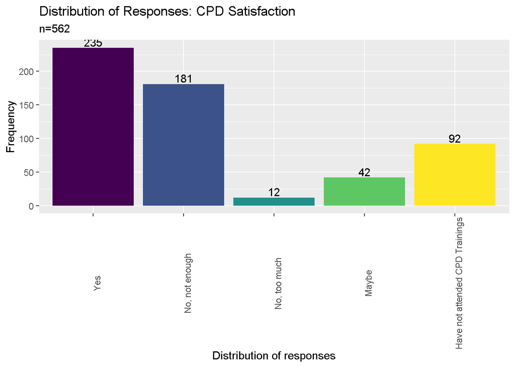

```r
# Change the factor type
dataset$cpdsatisfaction <- as.factor(dataset$cpdsatisfaction)
# Recode responses
levels(dataset$cpdsatisfaction)[1] <- "Maybe"
levels(dataset$cpdsatisfaction)[2] <- "Have not attended CPD Trainings"
levels(dataset$cpdsatisfaction)[3] <- "No, not enough"
levels(dataset$cpdsatisfaction)[4] <- "No, too much"
levels(dataset$cpdsatisfaction)[5] <- "Yes"
# Rearrange the responses
dataset$cpdsatisfaction <- factor(dataset$cpdsatisfaction, levels = c("Yes", "No, not enough", "No, too much", "Maybe", "Have not attended CPD Trainings"))
# Graph the data
dataset %>%
filter(!is.na(cpdsatisfaction)) %>%
ggplot(aes(x = cpdsatisfaction, fill = cpdsatisfaction)) + geom_bar() + geom_text(aes(label = ..count..), stat = "count", vjust = -0.2, colour = "black") + xlab("Distribution of responses") + ylab("Frequency") + ggtitle("Distribution of Responses: CPD Satisfaction", "n=562") + guides(fill = "none") + theme(axis.text.x = element_text(angle = 90)) + scale_fill_viridis_d()
```

## Question: Kindly indicate any challenges you encounter when fulfilling the required CPD trainings

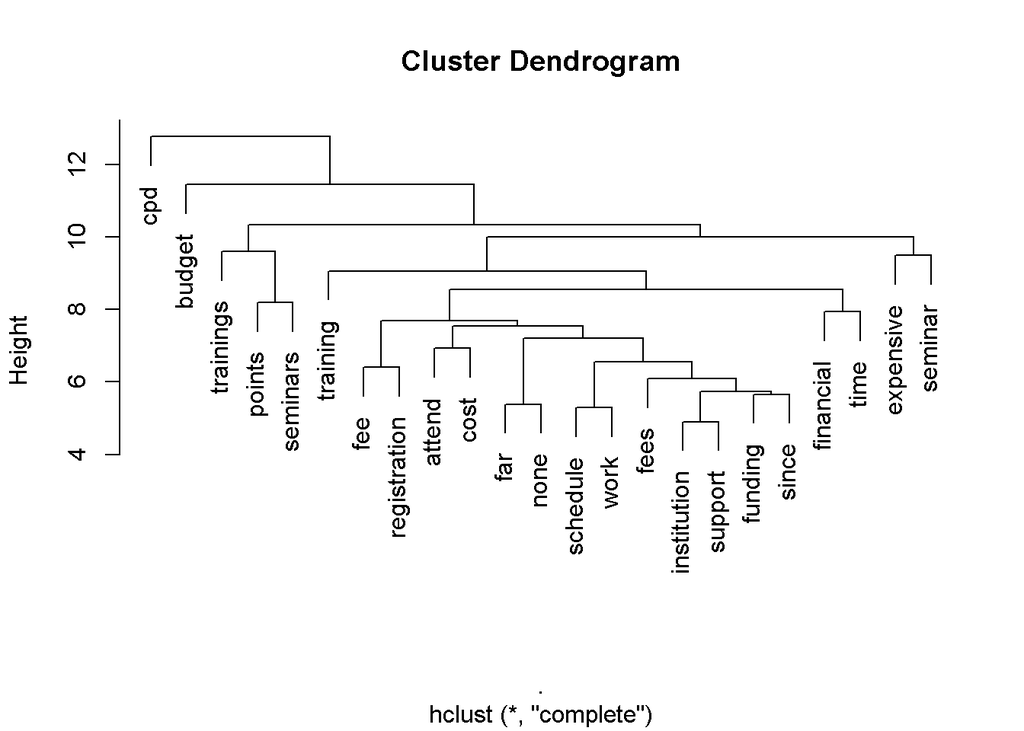

```r
# Create a clean_corpus function
clean_corpus <- function(corpus) {
    corpus <- tm_map(corpus, removePunctuation)
    corpus <- tm_map(corpus, removeNumbers)
    corpus <- tm_map(corpus, content_transformer(tolower))
    corpus <- tm_map(corpus, removeWords, c(stopwords("en")))
    corpus <- tm_map(corpus, stripWhitespace)
    return(corpus)
}
# Create a text dataset
cpdbarriers.text <- paste(dataset$cpdbarriers1, dataset$cpdbarriers2, dataset$cpdbarriers3)
# Create a text corpus
cpdbarriers.corpus <- cpdbarriers.text %>%
VectorSource() %>%
VCorpus()
# Clean the created corpus
cpdbarriers.corpus <- clean_corpus(cpdbarriers.corpus)
# Create a dendogram
cpdbarriers.corpus %>%
TermDocumentMatrix() %>%
removeSparseTerms(sparse = 0.98) %>%
as.matrix() %>%
dist() %>%
hclust() %>%
plot()
```

## Kindly indicate any topics you wish to explore in future trainings

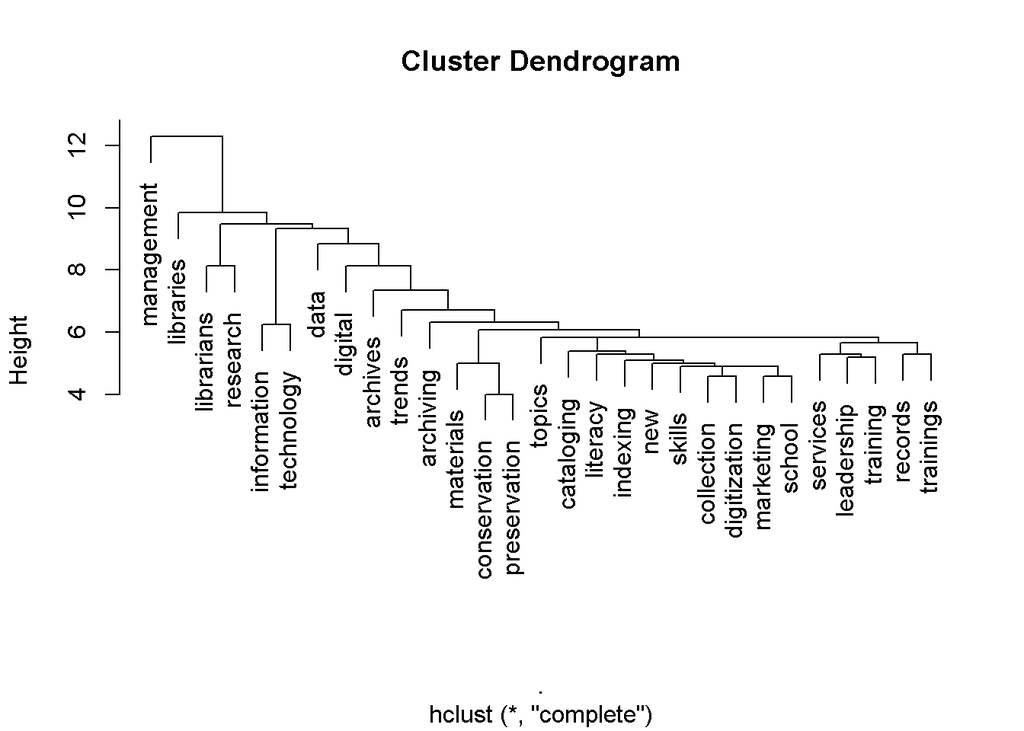

```r
# Create a clean_corpus function
clean_corpus <- function(corpus) {
    corpus <- tm_map(corpus, removePunctuation)
    corpus <- tm_map(corpus, removeNumbers)
    corpus <- tm_map(corpus, content_transformer(tolower))
    corpus <- tm_map(corpus, removeWords, c(stopwords("en"), "library", "librarianship"))
    corpus <- tm_map(corpus, stripWhitespace)
    return(corpus)
}
# Create a text dataset
topics.text <- paste(dataset$topics1, dataset$topics2, dataset$topics3, dataset$topics4, dataset$topics5)
# Create a text corpus
topics.corpus <- topics.text %>%
VectorSource() %>%
VCorpus()
# Clean the created corpus
topics.corpus <- clean_corpus(topics.corpus)
# Create a dendogram
topics.corpus %>%
TermDocumentMatrix() %>%
removeSparseTerms(sparse = 0.985) %>%
as.matrix() %>%
dist() %>%
hclust() %>%
plot()
```

## Kindly indicate your primary work location

- NCR
- Region I
- Region II
- CAR
- Region III
- Region IV
- Region V
- Region VI
- Region VII
- Region VIII
- Region IX
- Region X
- Region XI
- Region XII
- CARAGA
- ARMM

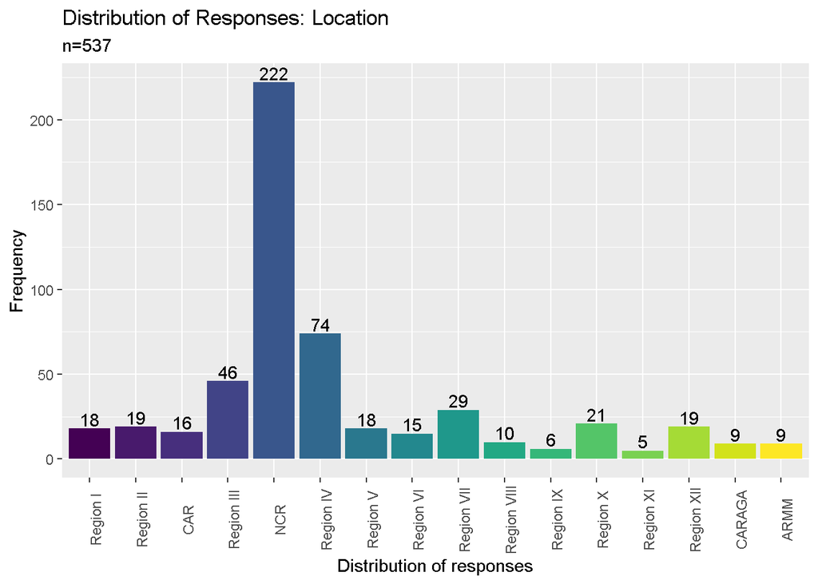

```r
# Change the factor type
dataset$location <- as.factor(dataset$location)
# Rearrange the responses
dataset$location <- factor(dataset$location, levels = c( 'Region I', 'Region II', 'CAR', 'Region III', 'NCR' , 'Region IV', 'Region V', 'Region VI', 'Region VII', 'Region VIII', 'Region IX','Region X', 'Region XI', 'Region XII', 'CARAGA' ,'ARMM'))
# Graph the data
dataset %>%
filter(!is.na(location)) %>%
ggplot(aes(x = location, fill = location)) + geom_bar() + geom_text(aes(label = ..count..), stat = "count", vjust = -0.2, colour = "black") + xlab("Distribution of responses") + ylab("Frequency") + ggtitle("Distribution of Responses: Location", "n=537") + guides(fill = "none") + theme(axis.text.x = element_text(angle = 90)) + scale_fill_viridis_d()
```

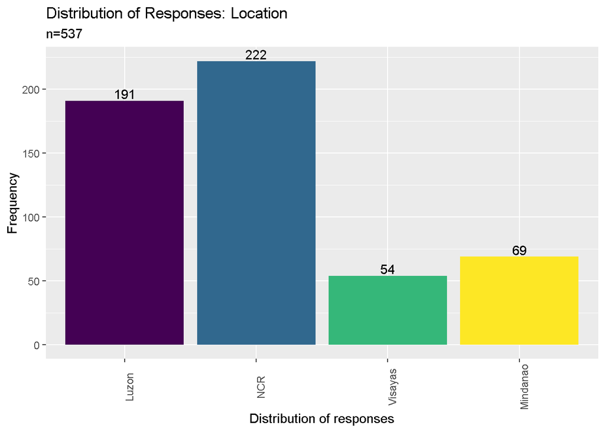

```r
# Create lvm column
dataset <- dataset %>%
mutate(lvm = location)
# Recode responses
dataset$lvm <- as.factor(dataset$lvm)
levels(dataset$lvm)[16] <- "Mindanao"
levels(dataset$lvm)[15] <- "Mindanao"
levels(dataset$lvm)[14] <- "Mindanao"
levels(dataset$lvm)[13] <- "Mindanao"
levels(dataset$lvm)[12] <- "Mindanao"
levels(dataset$lvm)[11] <- "Mindanao"
levels(dataset$lvm)[10] <- "Visayas"
levels(dataset$lvm)[9] <- "Visayas"
levels(dataset$lvm)[8] <- "Visayas"
levels(dataset$lvm)[7] <- "Luzon"
levels(dataset$lvm)[6] <- "Luzon"
levels(dataset$lvm)[5] <- "NCR"
levels(dataset$lvm)[4] <- "Luzon"
levels(dataset$lvm)[3] <- "Luzon"
levels(dataset$lvm)[2] <- "Luzon"
levels(dataset$lvm)[1] <- "Luzon"
# Graph the data
dataset %>%
filter(!is.na(lvm)) %>%
ggplot(aes(x = lvm, fill = lvm)) + geom_bar() + geom_text(aes(label = ..count..), stat = "count", vjust = -0.2, colour = "black") + xlab("Distribution of responses") + ylab("Frequency") + ggtitle("Distribution of Responses: Location", "n=537") + guides(fill = "none") + theme(axis.text.x = element_text(angle = 90)) + scale_fill_viridis_d()
```